# HST.953 Workshop 10: Regression Modeling

Wei-Hung Weng

Oct 28, 2016

## Instructions:

For those students taking the course for credit, the work done during this workshop is to be handed in. Please e-mail both your `Rmd` source file and `html` output to hst953hw@mit.edu no later than Friday Nov 4, 2016.

*To complete the assignment, fill in necessary code in the places indicated with `# Students: Insert your code here` and text based answers `### Student Answer`*

**Before beginning**, please test to see if the Rmd file will compile on your system by clicking the “Knit HTML button” in R studio above.

## Regression: The Basics

Regression in `R` has a nice unified framework for specifying regression models built around formulas. This framework is useful as it works for many different types of models, such that it’s very easy to transition from simple methods such as those used in this workshop, to very complex models, without having to learn a new syntax or format from scratch.

Formulae are of the form: `outcome ~ covariate_1 + covariate_2 + ... confounder_1 + confounder_2`. There are a couple of other quirks and shortcuts we will discuss soon enough.

## Linear Regression (OLS)

We will begin by loading the `aline-dataset.csv` file, and checking we have a complete dataset with the correct number of rows and columns (2751 and 50).

```r
dat <- read.csv("aline-dataset.csv")
dim(dat)
```

```
## [1] 2751   50
```

The workhorse function in `R` for linear regression is called `lm`. `lm` is best used with two arguments: 1) A model formula of the form we discussed in the previous section, and 2) a data frame to fit the model with. Let’s begin by plotting `bun_first` (covariate, x) and `creatinine_first` (outcome, y).

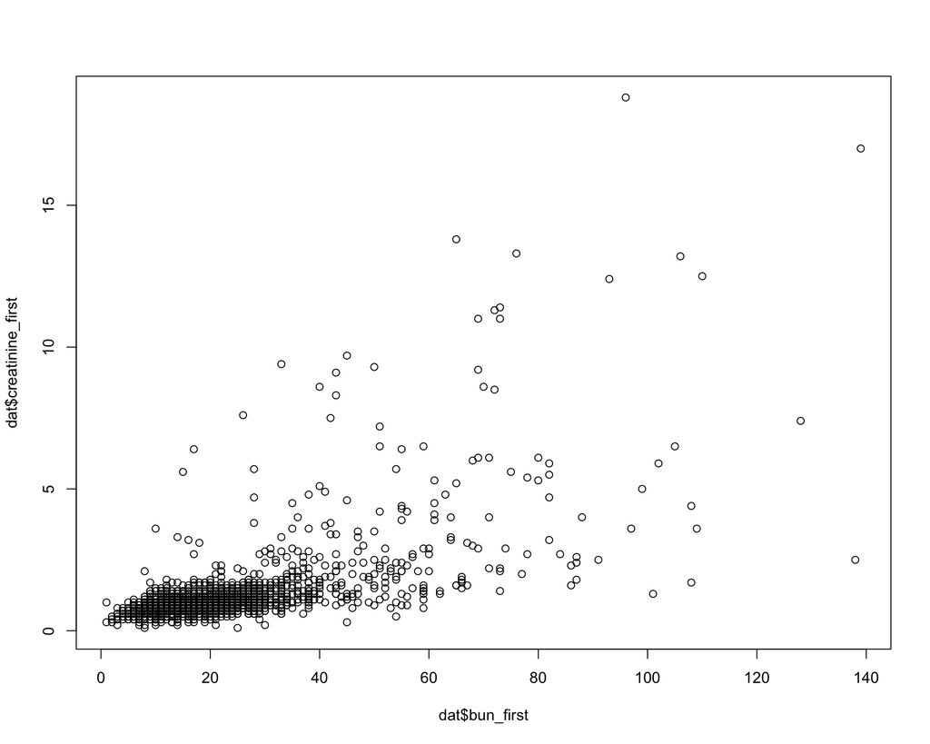

```r
plot(dat$bun_first,dat$creatinine_first)
```

We looked at this last time, and noted the large variability and number of outliers between these two clinical labs. Both of these can cause issues with regression models, and one way to address this is by transforming the data. For instance, we could `log` the `bun_first` values and take the inverse-cube root of the `creatinine_first` values (we will also negate this to preserve the ordering).

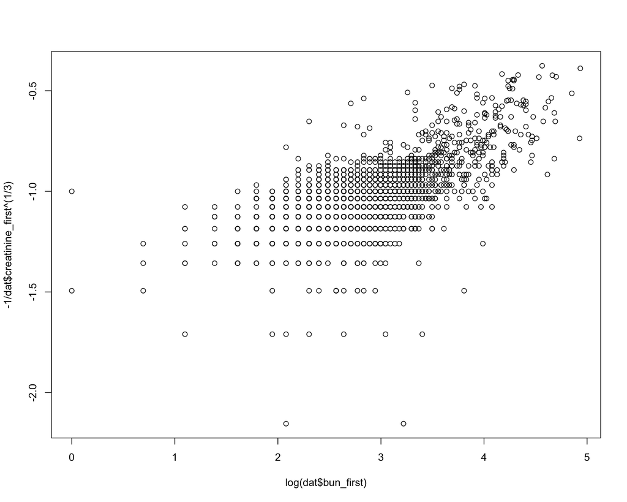

```r
plot(log(dat$bun_first),-1/dat$creatinine_first^(1/3))
```

The good news is that it appears we have stabilized the variance and reduce the number of problematic outliers, the complication is that when we fit linear regression models, the parameters will be estimated in terms of the transformed covariate *and* outcome. This makes it’s slightly more difficult to interpret.

Let us push forward and fit such a model. We could create a new column in our data frame with the transformed variables, but often we will be trying serveral types of transformations, and this can be burdensome. We can apply transformation directly in the formula. It’s not always necessary, but it’s a good idea to wrap any transformations in the `I` function. This tells `R` to evaluate what’s in the paratheses before fitting the model. This is important as the *^* operator means something different in a formula than elsewhere in `R`. The desired transformation and model fit can be done in one line as follows. Running the `summary` function on the new object, `bun.creat.lm` yields information about the model fit.

```r
bun.creat.lm <- lm(I(-1/dat$creatinine_first^(1/3)) ~ I(log(bun_first)),data=dat)
summary(bun.creat.lm)
```

```
##
## Call:
## lm(formula = I(-1/dat$creatinine_first^(1/3)) ~ I(log(bun_first)),
##     data = dat)
##
## Residuals:
##      Min       1Q   Median       3Q      Max
## -1.20080 -0.06640  0.00522  0.07274  0.51390
##
## Coefficients:
##                    Estimate Std. Error t value Pr(>|t|)
## (Intercept)       -1.513904   0.012709  -119.1   <2e-16 ***
## I(log(bun_first))  0.174056   0.004407    39.5   <2e-16 ***
## ---
## Signif. codes:  0 '***' 0.001 '**' 0.01 '*' 0.05 '.' 0.1 ' ' 1
##
## Residual standard error: 0.1238 on 2397 degrees of freedom
##   (352 observations deleted due to missingness)
## Multiple R-squared:  0.3942, Adjusted R-squared:  0.394
## F-statistic:  1560 on 1 and 2397 DF,  p-value: < 2.2e-16
```

```r
confint(bun.creat.lm)
```

```
##                        2.5 %    97.5 %
## (Intercept)       -1.5388256 -1.488982
## I(log(bun_first))  0.1654146  0.182698
```

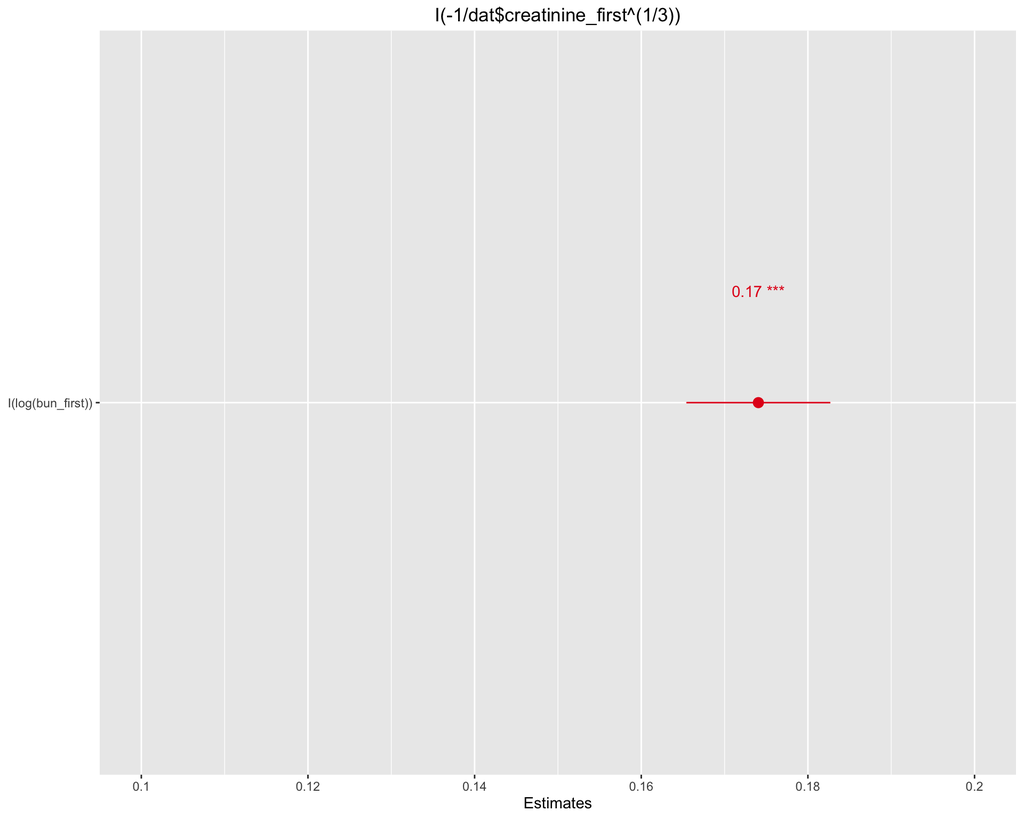

```r
#install.packages("sjPlot")
library(sjPlot)
sjp.lm(bun.creat.lm,type="coef")
```

We can add a best fit line to out plot above by using the `abline` function.

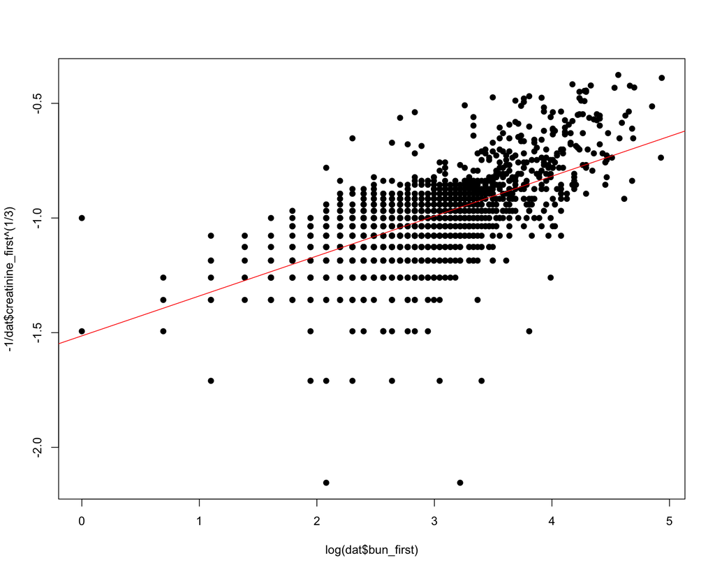

```r
plot(log(dat$bun_first),-1/dat$creatinine_first^(1/3),pch=19)
abline(bun.creat.lm,col='red')
```

As you may know, both of these labs are used to monitor the kidneys, and imagine now that your clinician collaborators believe that comorbidities related to the kidneys (`renal_flg`) would impact this relationship. As discussed in class, this impact can be in a number of different ways. Let’s examine this by fitting a separate intercept for each level of `renal_flg`, and then a model with a separate intercept *and* slope for each level. We will start by making `renal_flg` a factor.

```r
dat$renal_flg <- as.factor(dat$renal_flg)
```

Now let’s make the same plot as above, but will color code the data points by the `renal_flg` variable

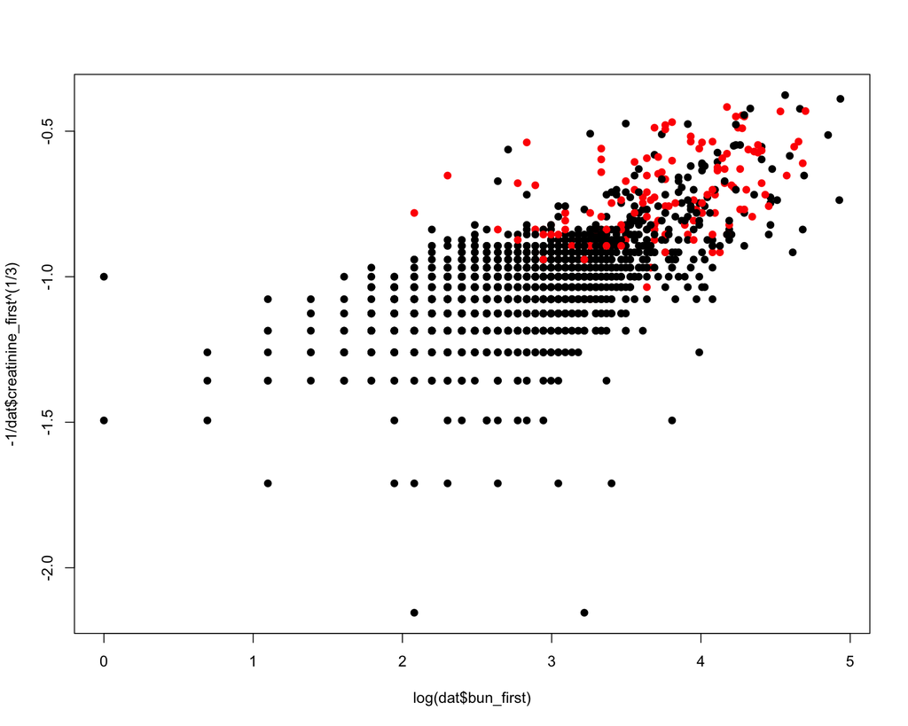

```r
plot(log(dat$bun_first),-1/dat$creatinine_first^(1/3),pch=19,col=dat$renal_flg)
```

Finally, let’s fit the two models, and run the `summary` function on each.

```r
bun.creat.renal.lm <-  lm(I(-1/dat$creatinine_first^(1/3)) ~ I(log(bun_first)) + renal_flg,data=dat)
summary(bun.creat.renal.lm)
```

```
##
## Call:
## lm(formula = I(-1/dat$creatinine_first^(1/3)) ~ I(log(bun_first)) +
##     renal_flg, data = dat)
##
## Residuals:
##      Min       1Q   Median       3Q      Max
## -1.18124 -0.06298  0.00574  0.07099  0.48646
##
## Coefficients:
##                    Estimate Std. Error t value Pr(>|t|)
## (Intercept)       -1.454587   0.012832 -113.36   <2e-16 ***
## I(log(bun_first))  0.149554   0.004541   32.93   <2e-16 ***
## renal_flg1         0.156751   0.010693   14.66   <2e-16 ***
## ---
## Signif. codes:  0 '***' 0.001 '**' 0.01 '*' 0.05 '.' 0.1 ' ' 1
##
## Residual standard error: 0.1186 on 2396 degrees of freedom
##   (352 observations deleted due to missingness)
## Multiple R-squared:  0.4441, Adjusted R-squared:  0.4436
## F-statistic:   957 on 2 and 2396 DF,  p-value: < 2.2e-16
```

```r
bun.creat.renal.int.lm <- lm(I(-1/dat$creatinine_first^(1/3)) ~ I(log(bun_first))*renal_flg,data=dat)
summary(bun.creat.renal.int.lm)
```

```
##
## Call:
## lm(formula = I(-1/dat$creatinine_first^(1/3)) ~ I(log(bun_first)) *
##     renal_flg, data = dat)
##
## Residuals:
##      Min       1Q   Median       3Q      Max
## -1.18073 -0.06278  0.00541  0.07075  0.48639
##
## Coefficients:
##                              Estimate Std. Error  t value Pr(>|t|)
## (Intercept)                  -1.45140    0.01324 -109.652   <2e-16 ***
## I(log(bun_first))             0.14841    0.00469   31.643   <2e-16 ***
## renal_flg1                    0.09075    0.06814    1.332    0.183
## I(log(bun_first)):renal_flg1  0.01842    0.01878    0.981    0.327
## ---
## Signif. codes:  0 '***' 0.001 '**' 0.01 '*' 0.05 '.' 0.1 ' ' 1
##
## Residual standard error: 0.1186 on 2395 degrees of freedom
##   (352 observations deleted due to missingness)
## Multiple R-squared:  0.4443, Adjusted R-squared:  0.4436
## F-statistic: 638.3 on 3 and 2395 DF,  p-value: < 2.2e-16
```

We can do hypothesis testing using the `anova` function and an F-test comparing the nested models. First `bun.creat.renal.lm` and `bun.creat.renal.int.lm`:

```r
anova(bun.creat.renal.lm,bun.creat.renal.int.lm)
```

```
## Analysis of Variance Table
##
## Model 1: I(-1/dat$creatinine_first^(1/3)) ~ I(log(bun_first)) + renal_flg
## Model 2: I(-1/dat$creatinine_first^(1/3)) ~ I(log(bun_first)) * renal_flg
##   Res.Df    RSS Df Sum of Sq      F Pr(>F)
## 1   2396 33.722
## 2   2395 33.708  1  0.013539 0.9619 0.3268
```

There doesn’t appear to be any statistically significant evidence that the relationship between the transformed forms of creatinine and BUN requires separate slopes. Do we need the `renal_flg` effect at all? Again we have nested models, and can use `anova`:

```r
anova(bun.creat.lm,bun.creat.renal.lm)
```

```
## Analysis of Variance Table
##
## Model 1: I(-1/dat$creatinine_first^(1/3)) ~ I(log(bun_first))
## Model 2: I(-1/dat$creatinine_first^(1/3)) ~ I(log(bun_first)) + renal_flg
##   Res.Df    RSS Df Sum of Sq      F    Pr(>F)
## 1   2397 36.746
## 2   2396 33.722  1    3.0242 214.88 < 2.2e-16 ***
## ---
## Signif. codes:  0 '***' 0.001 '**' 0.01 '*' 0.05 '.' 0.1 ' ' 1
```

Here, there does appear to be statistically significant evidence that the renal effect is non-zero.

Let’s plot the points again, and the two lines representing patients with a renal comorbidity (red), and those without (black points, blue, line):

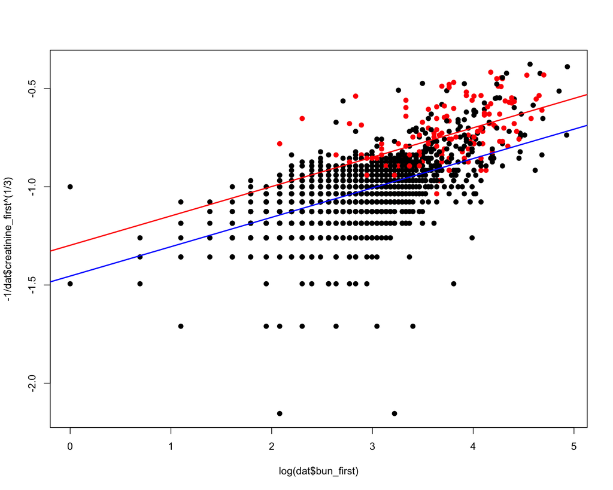

```r
plot(log(dat$bun_first),-1/dat$creatinine_first^(1/3),pch=19,col=dat$renal_flg)
abline(a=coef(bun.creat.renal.lm)[1],b=coef(bun.creat.renal.lm)[2],col="blue",lwd=2)
abline(a=sum(coef(bun.creat.renal.lm)[c(1,3)]),b=coef(bun.creat.renal.lm)[2],col="red",lwd=2)
```

### Student Question 1:

> 1. Make an appropriate plot to visual SOFA scores `sofa_first` by service unit (`service_unit`).
> 2. Some of the services have small number of patients. Create a new variable called `service_unit2` with any service with less than 200 patients lumped into a new category, “Other”. Plot these new categories as you did in part a). Comment briefly about any conclusions you would draw based on the figure.
> 3. Fit a regression with `sofa_first` as the outcome and `service_unit2` as a covariate. Pick one service unit, explain what the estimated coefficient means, include a 95% confidence interval and a p-value.
> 4. Conduct a hypothesis test to assess if the mean SOFA score is the same for all service units.
> 5. Add the `log(bun_first)` to your model in part c) (you do not need to consider an interaction). Test if the coefficient for `log(bun_first)` is zero. Interpret this new effect.

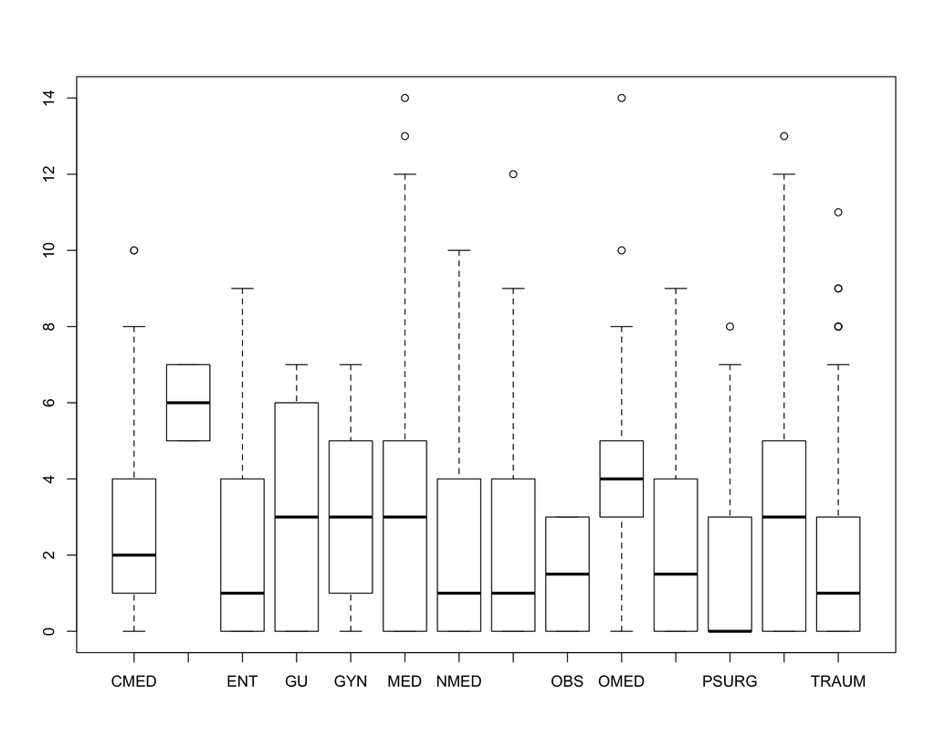

```r
# a
plot(dat$service_unit, dat$sofa_first)
```

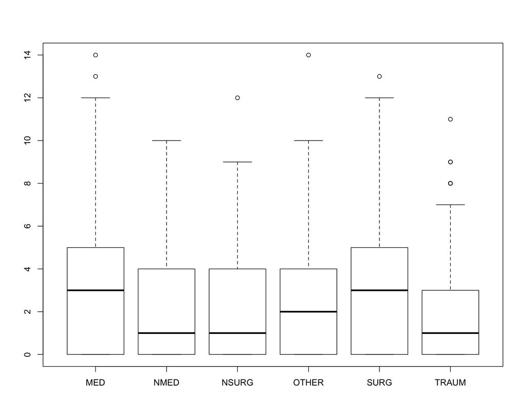

```r
# b
dat$service_unit2 <- as.factor(ifelse(dat$service_unit %in% names(table(dat$service_unit)[table(dat$service_unit) < 200]),
                                      "OTHER",
                                      as.character(dat$service_unit)))
plot(dat$service_unit2, dat$sofa_first)
```

```r
# c
sofa.unit2.lm <- lm(sofa_first ~ service_unit2, data=dat)
summary(sofa.unit2.lm)
```

```
##
## Call:
## lm(formula = sofa_first ~ service_unit2, data = dat)
##
## Residuals:
##     Min      1Q  Median      3Q     Max
## -3.3545 -2.0972 -0.3545  1.7311 11.3879
##
## Coefficients:
##                    Estimate Std. Error t value Pr(>|t|)
## (Intercept)         3.04268    0.08072  37.696  < 2e-16 ***
## service_unit2NMED  -0.77377    0.15916  -4.862 1.23e-06 ***
## service_unit2NSURG -0.78728    0.17515  -4.495 7.25e-06 ***
## service_unit2OTHER -0.43056    0.16392  -2.627  0.00867 **
## service_unit2SURG   0.31187    0.19248   1.620  0.10529
## service_unit2TRAUM -0.94548    0.13810  -6.846 9.30e-12 ***
## ---
## Signif. codes:  0 '***' 0.001 '**' 0.01 '*' 0.05 '.' 0.1 ' ' 1
##
## Residual standard error: 2.592 on 2745 degrees of freedom
## Multiple R-squared:  0.0278, Adjusted R-squared:  0.02603
## F-statistic:  15.7 on 5 and 2745 DF,  p-value: 2.884e-15
```

```r
confint(sofa.unit2.lm)
```

```
##                          2.5 %     97.5 %
## (Intercept)         2.88440445  3.2009496
## service_unit2NMED  -1.08584969 -0.4616892
## service_unit2NSURG -1.13072306 -0.4438396
## service_unit2OTHER -0.75197938 -0.1091322
## service_unit2SURG  -0.06554986  0.6892867
## service_unit2TRAUM -1.21626577 -0.6746957
```

```r
# d
anova(sofa.unit2.lm)
```

```
## Analysis of Variance Table
##
## Response: sofa_first
##                 Df  Sum Sq Mean Sq F value    Pr(>F)
## service_unit2    5   527.3 105.454  15.699 2.884e-15 ***
## Residuals     2745 18438.8   6.717
## ---
## Signif. codes:  0 '***' 0.001 '**' 0.01 '*' 0.05 '.' 0.1 ' ' 1
```

```r
# e
sofa.unit2.bun.lm <- lm(sofa_first ~ service_unit2 + I(log(bun_first)), data=dat)
summary(sofa.unit2.bun.lm)
```

```
##
## Call:
## lm(formula = sofa_first ~ service_unit2 + I(log(bun_first)),
##     data = dat)
##
## Residuals:
##     Min      1Q  Median      3Q     Max
## -4.1371 -2.1130 -0.5052  1.6391 10.8913
##
## Coefficients:
##                    Estimate Std. Error t value Pr(>|t|)
## (Intercept)         0.59703    0.28519   2.093  0.03641 *
## service_unit2NMED  -0.75042    0.16440  -4.564 5.26e-06 ***
## service_unit2NSURG -0.80601    0.18178  -4.434 9.67e-06 ***
## service_unit2OTHER -0.27091    0.18942  -1.430  0.15279
## service_unit2SURG   0.65493    0.20499   3.195  0.00142 **
## service_unit2TRAUM -0.82606    0.14292  -5.780 8.45e-09 ***
## I(log(bun_first))   0.88745    0.09258   9.585  < 2e-16 ***
## ---
## Signif. codes:  0 '***' 0.001 '**' 0.01 '*' 0.05 '.' 0.1 ' ' 1
##
## Residual standard error: 2.54 on 2396 degrees of freedom
##   (348 observations deleted due to missingness)
## Multiple R-squared:  0.07787,    Adjusted R-squared:  0.07556
## F-statistic: 33.72 on 6 and 2396 DF,  p-value: < 2.2e-16
```

```r
confint(sofa.unit2.bun.lm)
```

```
##                         2.5 %     97.5 %
## (Intercept)         0.0377833  1.1562734
## service_unit2NMED  -1.0728091 -0.4280317
## service_unit2NSURG -1.1624629 -0.4495507
## service_unit2OTHER -0.6423477  0.1005346
## service_unit2SURG   0.2529613  1.0569071
## service_unit2TRAUM -1.1063268 -0.5457972
## I(log(bun_first))   0.7058972  1.0690033
```

## Logistic Regression

Luckily the same framework for linear regression works for logistic regression. The main difference are two fold:

1. We need to use a different function, called `glm` instead of `lm`.
2. We need an additional argument (`family="binomial"`) telling `R` we wish to do a logistic regression.

For example, let’s say we want to estimate the effect of aline has on 28 day mortality:

```r
aline.glm <- glm(day_28_flg ~ aline_flg,data=dat,family="binomial")
summary(aline.glm)
```

```
##
## Call:
## glm(formula = day_28_flg ~ aline_flg, family = "binomial", data = dat)
##
## Deviance Residuals:
##     Min       1Q   Median       3Q      Max
## -0.5736  -0.5736  -0.5732  -0.5732   1.9429
##
## Coefficients:
##              Estimate Std. Error z value Pr(>|z|)
## (Intercept) -1.721379   0.075647 -22.756   <2e-16 ***
## aline_flg   -0.001726   0.106338  -0.016    0.987
## ---
## Signif. codes:  0 '***' 0.001 '**' 0.01 '*' 0.05 '.' 0.1 ' ' 1
##
## (Dispersion parameter for binomial family taken to be 1)
##
##     Null deviance: 2340.8  on 2750  degrees of freedom
## Residual deviance: 2340.8  on 2749  degrees of freedom
## AIC: 2344.8
##
## Number of Fisher Scoring iterations: 4
```

```r
exp(coef(aline.glm)[1])
```

```
## (Intercept)
##   0.1788194
```

```r
confint(aline.glm)
```

```
##                  2.5 %     97.5 %
## (Intercept) -1.8722799 -1.5755922
## aline_flg   -0.2102011  0.2068694
```

```r
exp(confint(aline.glm))
```

```
##                 2.5 %   97.5 %
## (Intercept) 0.1537727 0.206885
## aline_flg   0.8104212 1.229822
```

It’s often convenient to summarise this information all in one plot or table, and the `sjPlot` package can help us do both:

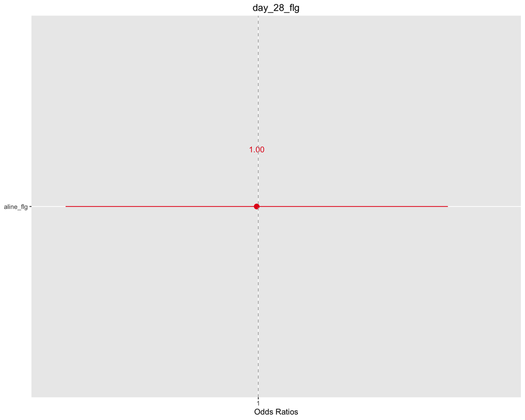

|  |  | OR | CI | p |
| --- | --- | --- | --- | --- |
| (Intercept) |  | 0.18 | 0.15 – 0.21 | **<.001** |
| aline_flg |  | 1.00 | 0.81 – 1.23 | .987 |
| Observations |  | 2751 |  |  |

```r
library(sjPlot)
sjp.glm(aline.glm)
```

For comparison, let’s try to see what happens when we estimate this using 2 x 2 tables:

```r
tab22 <- table(dat$aline_flg,dat$day_28_flg,dnn=c("Aline","28 Day Death"))
tab22
```

```
##      28 Day Death
## Aline    0    1
##     0 1152  206
##     1 1182  211
```

```r
ptab22 <- prop.table(tab22,1)
ptab22
```

```
##      28 Day Death
## Aline         0         1
##     0 0.8483063 0.1516937
##     1 0.8485284 0.1514716
```

```r
Odds22 <- ptab22[,2]/ptab22[,1]
Odds22
```

```
##         0         1
## 0.1788194 0.1785110
```

```r
Odds22[2]/Odds22[1]
```

```
##         1
## 0.9982751
```

The last number, the estimated odds ratio corresponds to the `aline_flg` row in the previous `sjt.glm` table, while the first element of `Odds22`, 0.1788194 corresponds to the odds of 28 day death in the no aline group (i.e. the intercept). Both match up, as is generally expected when comparing the two approaches with one covariate at a time.

One of the benefits that logistic regression has over something like 2x2 tables, is that it can handle continuous covariates and confounders quite easily. For example let’s look at `sofa_first` as the covariate and `day_28_flg` as the outcome.

```r
sofa.glm <- glm(day_28_flg ~ sofa_first,data=dat,family="binomial")
summary(sofa.glm)
```

```
##
## Call:
## glm(formula = day_28_flg ~ sofa_first, family = "binomial", data = dat)
##
## Deviance Residuals:
##     Min       1Q   Median       3Q      Max
## -0.7892  -0.5938  -0.5435  -0.5276   2.0203
##
## Coefficients:
##             Estimate Std. Error z value Pr(>|z|)
## (Intercept) -1.90170    0.07843 -24.246  < 2e-16 ***
## sofa_first   0.06392    0.01942   3.291 0.000999 ***
## ---
## Signif. codes:  0 '***' 0.001 '**' 0.01 '*' 0.05 '.' 0.1 ' ' 1
##
## (Dispersion parameter for binomial family taken to be 1)
##
##     Null deviance: 2340.8  on 2750  degrees of freedom
## Residual deviance: 2330.2  on 2749  degrees of freedom
## AIC: 2334.2
##
## Number of Fisher Scoring iterations: 4
```

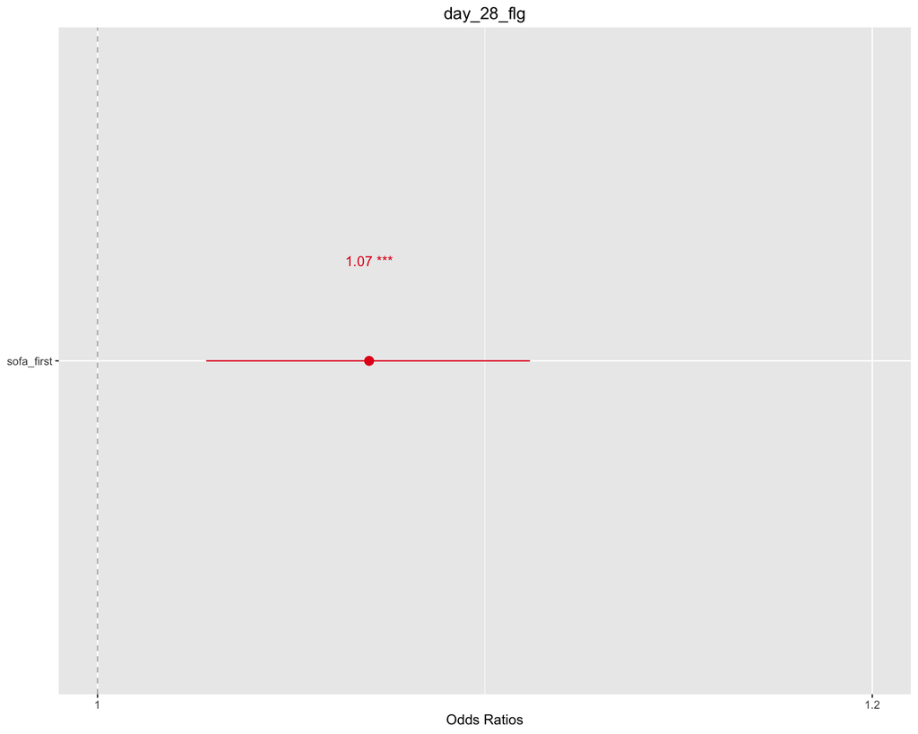

```r
sjp.glm(sofa.glm)
```

Here we see that the estimated odds of death increases about 7% (OR=1.07, 95% CI: 1.03-1.11, per unit increase in SOFA) and this is quite statistically significant (p<0.001).

This presumes of course that the relationship between the log odds of death and SOFA is linear, which need not be the case. There are several ways to formally test this, but assessing this visually can be useful.

```r
library(MIMICbook); library(Hmisc)
```

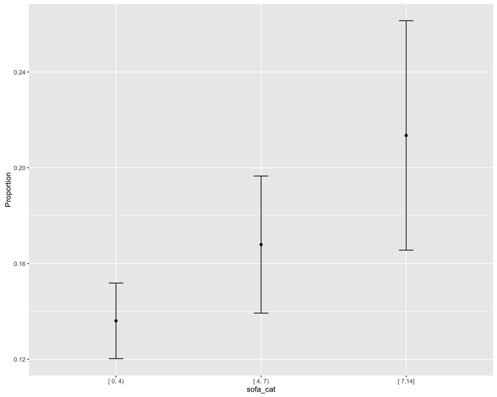

```r
dat$sofa_cat <- cut2(dat$sofa_first,c(0,4,7))
plot_prop_by_level(dat,"sofa_cat","day_28_flg")
```

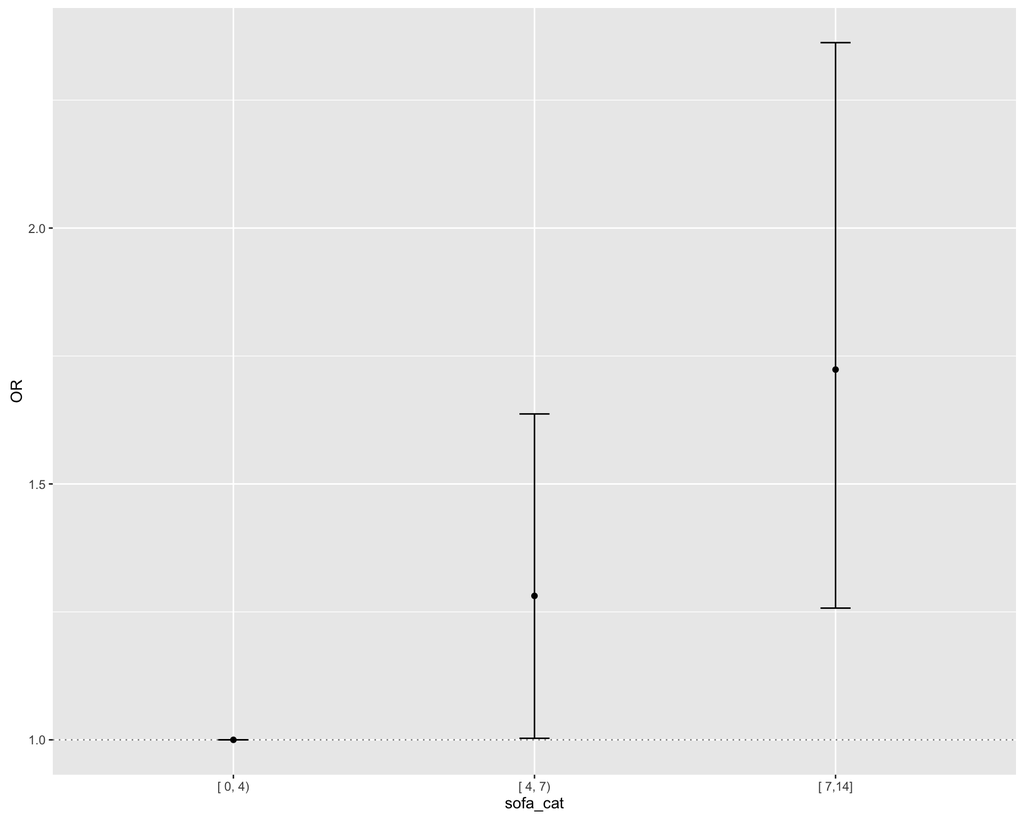

```r
plot_OR_by_level(dat,"sofa_cat","day_28_flg")
```

While not quite what we want (log odds of death by level), these plots suggest that the risk of death generally increases monotonically as SOFA increases.

Let’s combine the two models, and try to estimate the effect of `aline_flg` on 28 day mortality, while adjusting for SOFA.

```r
aline.sofa.glm <- glm(day_28_flg ~ aline_flg + sofa_first,data=dat,family="binomial")
summary(aline.sofa.glm)
```

```
##
## Call:
## glm(formula = day_28_flg ~ aline_flg + sofa_first, family = "binomial",
##     data = dat)
##
## Deviance Residuals:
##     Min       1Q   Median       3Q      Max
## -0.7880  -0.5928  -0.5445  -0.5266   2.0220
##
## Coefficients:
##              Estimate Std. Error z value Pr(>|z|)
## (Intercept) -1.897855   0.094501 -20.083  < 2e-16 ***
## aline_flg   -0.007754   0.106574  -0.073 0.942001
## sofa_first   0.063946   0.019429   3.291 0.000997 ***
## ---
## Signif. codes:  0 '***' 0.001 '**' 0.01 '*' 0.05 '.' 0.1 ' ' 1
##
## (Dispersion parameter for binomial family taken to be 1)
##
##     Null deviance: 2340.8  on 2750  degrees of freedom
## Residual deviance: 2330.2  on 2748  degrees of freedom
## AIC: 2336.2
##
## Number of Fisher Scoring iterations: 4
```

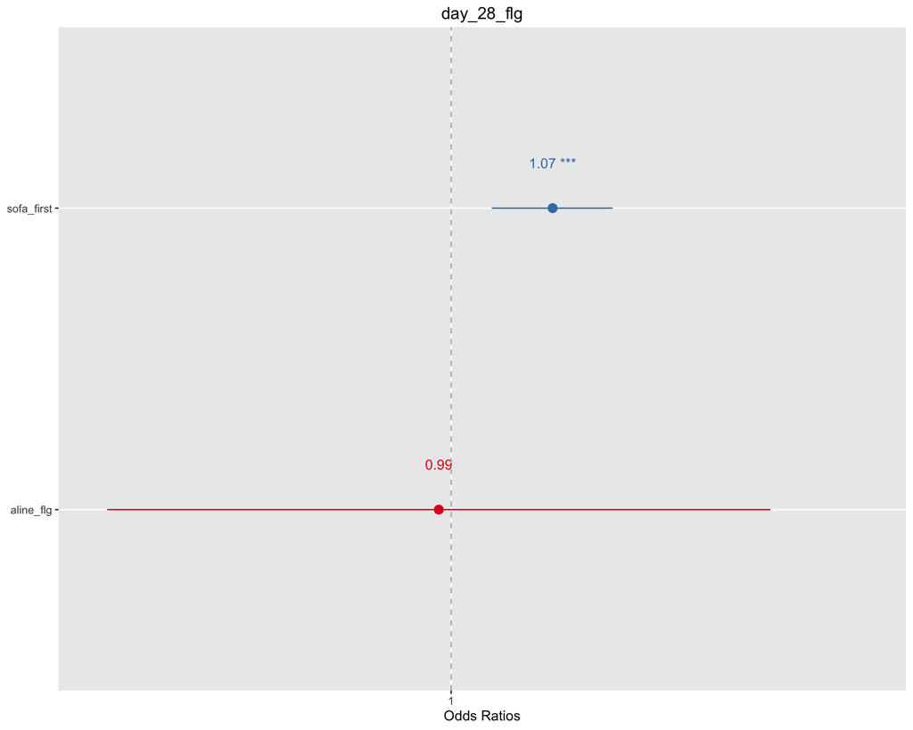

```r
sjp.glm(aline.sofa.glm)
```

```r
exp(coef(aline.sofa.glm))
```

```
## (Intercept)   aline_flg  sofa_first
##   0.1498898   0.9922763   1.0660352
```

```r
exp(confint((aline.sofa.glm)))
```

```
##                 2.5 %    97.5 %
## (Intercept) 0.1241971 0.1799099
## aline_flg   0.8051703 1.2229821
## sofa_first  1.0259315 1.1071730
```

Here, we see not much changes. The adjusted odds ratio for `aline_flg` is 0.99, 95% CI: 0.80-1.22, p=0.94. Based on this model, there’s little statistically significant evidence to conclude that aline improves this outcome, while adjusting for SOFA.

As was the case for linear regression, we can run a hypothesis test for nested models using the `anova` function When the difference between the nested models is only one *term*, often the p-value (`Pr(>|z|)`) listed in the summary output will be close to that using a likelihood ratio test using the `anova` function, but this latter method can be in the case where testing more than one effect simulaneously is required (e.g., multi-level categorical variables).

To test the statistical significance of `aline_flg`, we would compare the model with `aline_flg` and `sofa_first` to the model with just `sofa_first` as:

```r
anova(sofa.glm,aline.sofa.glm,test="Chisq")
```

```
## Analysis of Deviance Table
##
## Model 1: day_28_flg ~ sofa_first
## Model 2: day_28_flg ~ aline_flg + sofa_first
##   Resid. Df Resid. Dev Df  Deviance Pr(>Chi)
## 1      2749     2330.2
## 2      2748     2330.2  1 0.0052931    0.942
```

where `test="Chisq"` is an appropriate setting for logistic regression.

### Student Question 2:

> 1. Fit a logistic regression between `aline_flg` and in hospital death (`hosp_exp_flg`). Interpret and briefly explain the results of this model.
> 2. Fit a model with `age` as a continuous covariate for the same outcome (`hosp_exp_flg`). Check to see if this is an appropriate form to use age in the model.
> 3. You can fit a model in a subset of the data using the `subset` parameter in `glm`. For example, `subset=age<100`, includes only patients with age less than 100 in the model fit. Repeat b), in this subset. Do your results change? Why or why not?
> 4. Regardless of your response in c), fit a logistic regression with age as a categorical variable (column) called `age.cat` using the `cut2` function and `cuts` argument: `c(50,60,70,80)`, and the `aline_flg` variable for the `hosp_exp_flg` outcome. Interpret and present your results. Perform a hypothesis test two ways for the effect of `aline_flg`. Use the entire data set, i.e., without any subset argument.
> 5. For the first model fit in part d), explain in no more than 50 words what the intercept means in this model.

```r
# a
aline.glm <- glm(hosp_exp_flg ~ aline_flg, data=dat, family="binomial")
summary(aline.glm)
```

```
##
## Call:
## glm(formula = hosp_exp_flg ~ aline_flg, family = "binomial",
##     data = dat)
##
## Deviance Residuals:
##     Min       1Q   Median       3Q      Max
## -0.5338  -0.5338  -0.5090  -0.5090   2.0532
##
## Coefficients:
##             Estimate Std. Error z value Pr(>|z|)
## (Intercept) -1.97828    0.08306 -23.818   <2e-16 ***
## aline_flg    0.10192    0.11459   0.889    0.374
## ---
## Signif. codes:  0 '***' 0.001 '**' 0.01 '*' 0.05 '.' 0.1 ' ' 1
##
## (Dispersion parameter for binomial family taken to be 1)
##
##     Null deviance: 2096.7  on 2750  degrees of freedom
## Residual deviance: 2095.9  on 2749  degrees of freedom
## AIC: 2099.9
##
## Number of Fisher Scoring iterations: 4
```

```r
exp(coef(aline.glm)[1])
```

```
## (Intercept)
##   0.1383068
```

```r
confint(aline.glm)
```

```
##                  2.5 %     97.5 %
## (Intercept) -2.1445316 -1.8187312
## aline_flg   -0.1224792  0.3270431
```

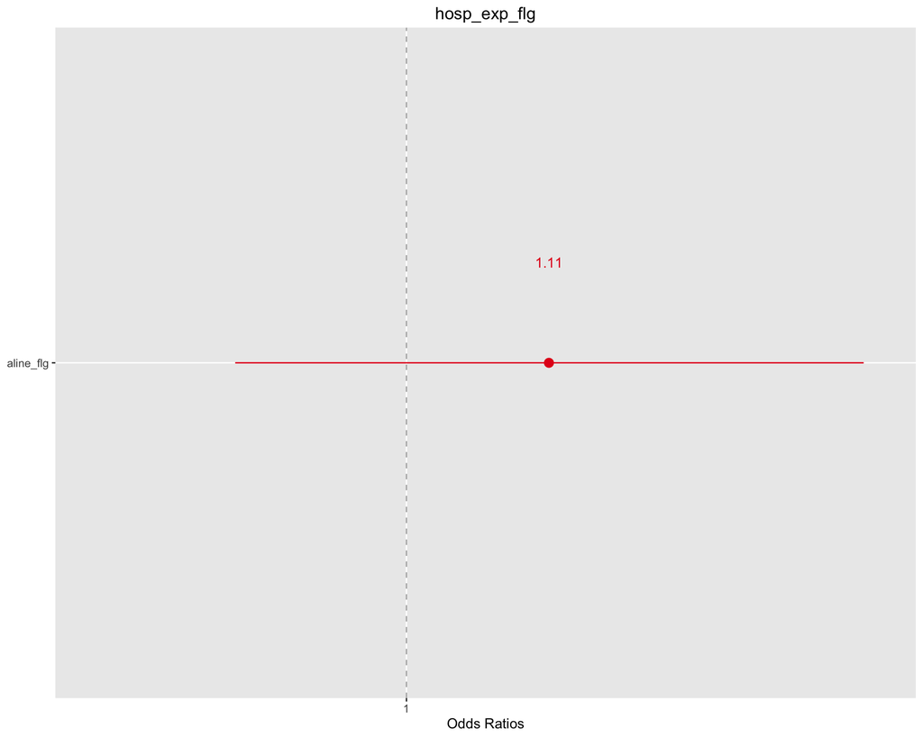

```r
sjp.glm(aline.glm)
```

```r
# b
age.glm <- glm(hosp_exp_flg ~ age, data=dat, family="binomial")
summary(age.glm)
```

```
##
## Call:
## glm(formula = hosp_exp_flg ~ age, family = "binomial", data = dat)
##
## Deviance Residuals:
##     Min       1Q   Median       3Q      Max
## -1.1644  -0.5085  -0.4734  -0.4351   2.2196
##
## Coefficients:
##               Estimate Std. Error z value Pr(>|z|)
## (Intercept) -2.5603413  0.0876267  -29.22   <2e-16 ***
## age          0.0084315  0.0007861   10.72   <2e-16 ***
## ---
## Signif. codes:  0 '***' 0.001 '**' 0.01 '*' 0.05 '.' 0.1 ' ' 1
##
## (Dispersion parameter for binomial family taken to be 1)
##
##     Null deviance: 2096.7  on 2750  degrees of freedom
## Residual deviance: 1992.8  on 2749  degrees of freedom
## AIC: 1996.8
##
## Number of Fisher Scoring iterations: 4
```

```r
exp(coef(age.glm)[1])
```

```
## (Intercept)
##  0.07727836
```

```r
confint(age.glm)
```

```
##                    2.5 %       97.5 %
## (Intercept) -2.734166994 -2.390526929
## age          0.006888627  0.009976473
```

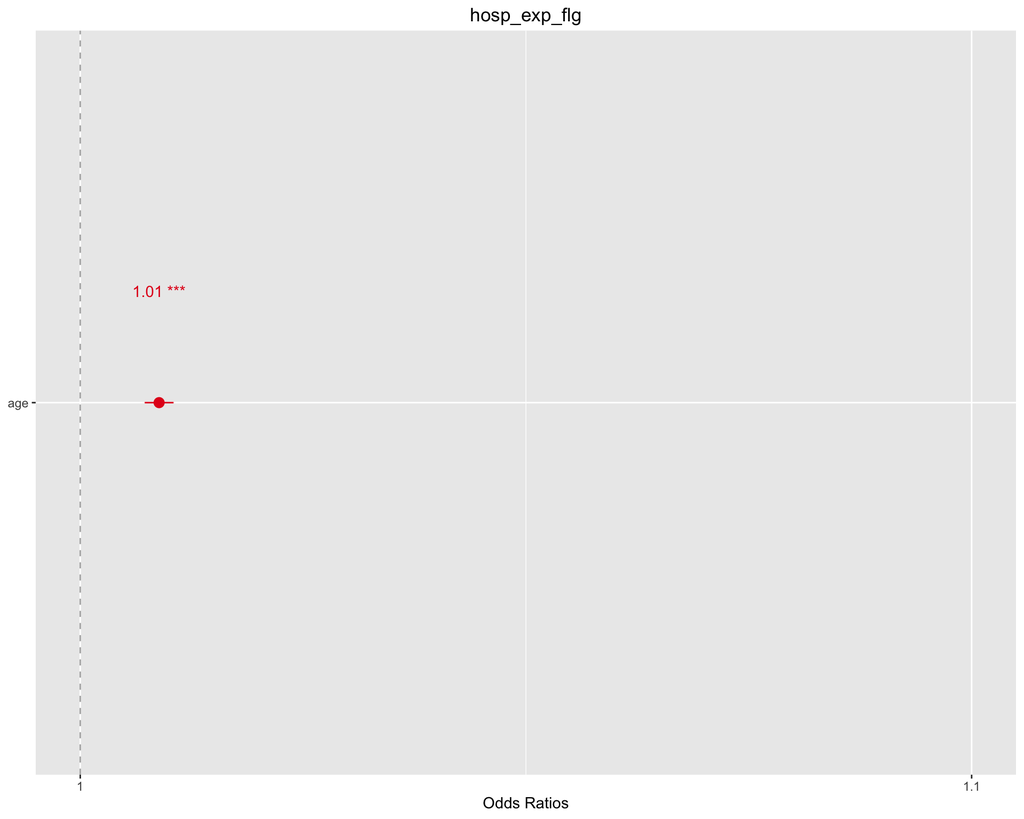

```r
sjp.glm(age.glm)
```

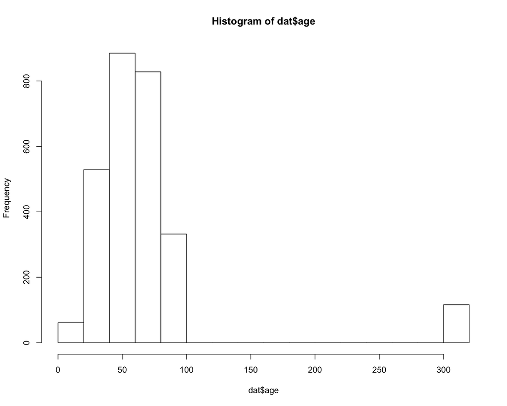

```r
hist(dat$age)
```

```r
# c
age.glm2 <- glm(hosp_exp_flg ~ age, data=dat, family="binomial", subset=age<100)
summary(age.glm2)
```

```
##
## Call:
## glm(formula = hosp_exp_flg ~ age, family = "binomial", data = dat,
##     subset = age < 100)
##
## Deviance Residuals:
##     Min       1Q   Median       3Q      Max
## -0.9385  -0.5552  -0.3587  -0.2081   2.9269
##
## Coefficients:
##              Estimate Std. Error z value Pr(>|z|)
## (Intercept) -5.482235   0.296739  -18.48   <2e-16 ***
## age          0.054969   0.004212   13.05   <2e-16 ***
## ---
## Signif. codes:  0 '***' 0.001 '**' 0.01 '*' 0.05 '.' 0.1 ' ' 1
##
## (Dispersion parameter for binomial family taken to be 1)
##
##     Null deviance: 1900.8  on 2634  degrees of freedom
## Residual deviance: 1678.0  on 2633  degrees of freedom
## AIC: 1682
##
## Number of Fisher Scoring iterations: 6
```

```r
exp(coef(age.glm2)[1])
```

```
## (Intercept)
##  0.00416002
```

```r
confint(age.glm2)
```

```
##                   2.5 %      97.5 %
## (Intercept) -6.08170882 -4.91771919
## age          0.04688656  0.06340781
```

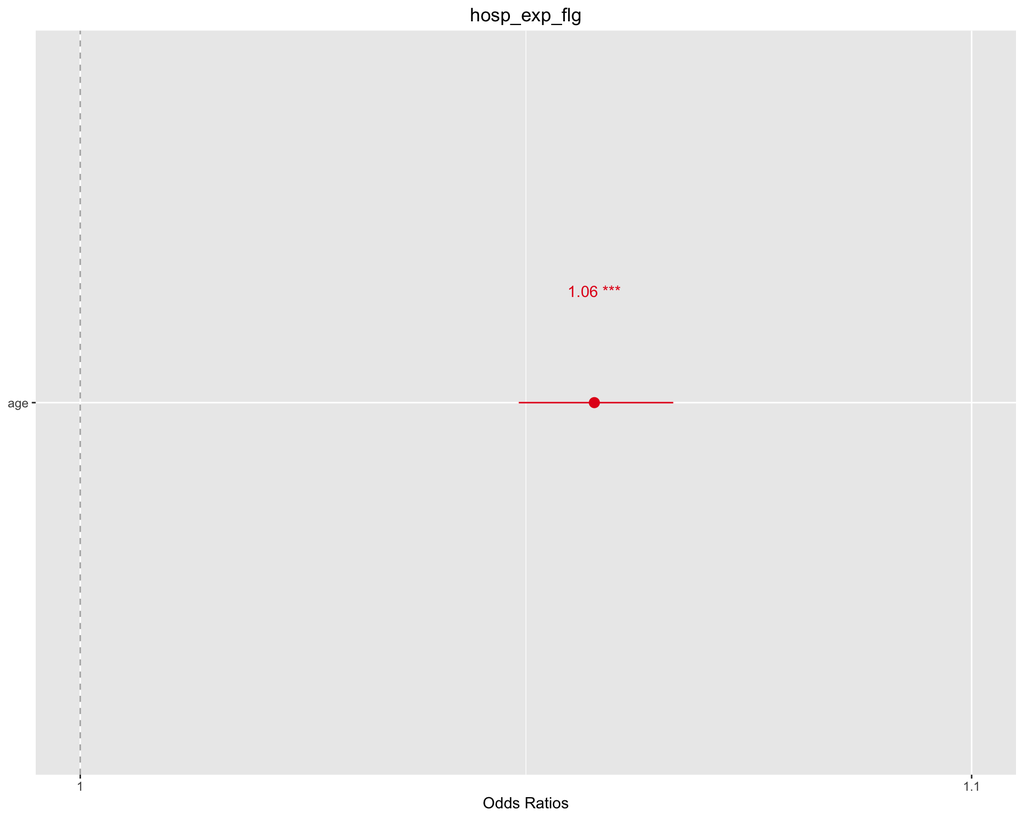

```r
sjp.glm(age.glm2)
```

```r
# d
dat$age.cat <- cut2(dat$age, c(50,60,70,80))
aline.agecat.glm <- glm(hosp_exp_flg ~ aline_flg + age.cat, data=dat, family="binomial")
summary(aline.agecat.glm)
```

```
##
## Call:
## glm(formula = hosp_exp_flg ~ aline_flg + age.cat, family = "binomial",
##     data = dat)
##
## Deviance Residuals:
##     Min       1Q   Median       3Q      Max
## -0.8748  -0.5895  -0.3889  -0.2403   2.6680
##
## Coefficients:
##                  Estimate Std. Error z value Pr(>|z|)
## (Intercept)       -3.5302     0.1930 -18.288  < 2e-16 ***
## aline_flg          0.1433     0.1206   1.188    0.235
## age.cat[ 50, 60)   0.9865     0.2519   3.916 8.99e-05 ***
## age.cat[ 60, 70)   1.7248     0.2296   7.513 5.79e-14 ***
## age.cat[ 70, 80)   2.0946     0.2185   9.587  < 2e-16 ***
## age.cat[ 80,300]   2.6237     0.2096  12.516  < 2e-16 ***
## ---
## Signif. codes:  0 '***' 0.001 '**' 0.01 '*' 0.05 '.' 0.1 ' ' 1
##
## (Dispersion parameter for binomial family taken to be 1)
##
##     Null deviance: 2096.7  on 2750  degrees of freedom
## Residual deviance: 1850.4  on 2745  degrees of freedom
## AIC: 1862.4
##
## Number of Fisher Scoring iterations: 6
```

```r
exp(coef(aline.agecat.glm)[1])
```

```
## (Intercept)
##  0.02929821
```

```r
confint(aline.agecat.glm)
```

```
##                        2.5 %     97.5 %
## (Intercept)      -3.92839945 -3.1694218
## aline_flg        -0.09276449  0.3804244
## age.cat[ 50, 60)  0.49342084  1.4850523
## age.cat[ 60, 70)  1.28274330  2.1858378
## age.cat[ 70, 80)  1.67731504  2.5366099
## age.cat[ 80,300]  2.22610282  3.0504068
```

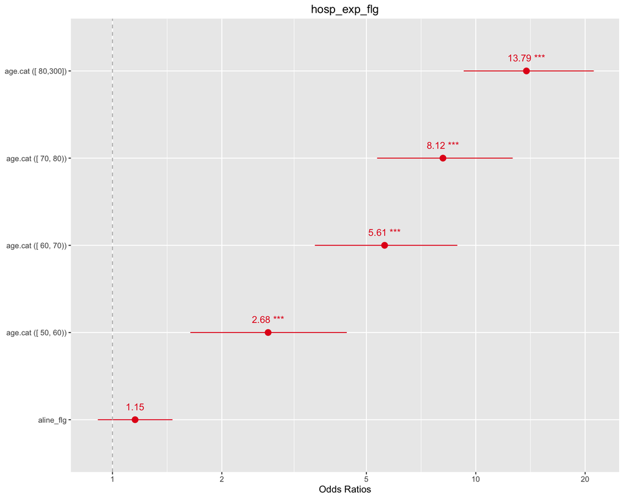

```r
sjp.glm(aline.agecat.glm)
```

```r
anova(aline.agecat.glm, test="Chisq")
```

```
## Analysis of Deviance Table
##
## Model: binomial, link: logit
##
## Response: hosp_exp_flg
##
## Terms added sequentially (first to last)
##
##
##           Df Deviance Resid. Df Resid. Dev Pr(>Chi)
## NULL                       2750     2096.7
## aline_flg  1    0.792      2749     2095.9   0.3735
## age.cat    4  245.534      2745     1850.4   <2e-16 ***
## ---
## Signif. codes:  0 '***' 0.001 '**' 0.01 '*' 0.05 '.' 0.1 ' ' 1
```

## Model Selection

The last topic in this workshop is related to model selection. Model selection is an important area, where the data analyst is trying to find the model which explains the data the best, while also being no more complicated than necessary, as to avoid overfitting, and more difficulties in interpretation. While there is no generally accepted best way to do model selection in our context, a couple of suggestions:

1. Outline a plan and criteria you will use to do the model selection before you begin, and try to stick to it.
2. Be transparent and reproducible in the methods you use.
3. Try to find problems in your model, not as to rescue is from p>0.05, but rather to see if your results are robust to other specificiations of the model.

In our case, we will examine a method known as stepwise forward selection. (We cover stepwise backwards selection in Chapter 16 in the textbook). There are many other approaches and methods which vary significantly in terms of their sophistication and assumptions.

In stepwise forward selection, we begin by specifying our covariate of interest (`aline_flg`), outcome (`day_28_flg`), and list (with form) of potential confounders:

1. age (<50, 50-60, 60-70,70-80, >80)
2. sofa (0-4, 4-6, >7)
3. service_unit (as defined earlier in this workshop for `service_unit2`)
4. Binary co-morbidities: `renal_flg`, `chf_flg`, `cad_flg`, `stroke_flg`, `mal_flg`, and `resp_flg`.

From a base model which includes only `aline_flg` and an intercept, we will add one variable at a time, by including the one with the smallest p-value, until we are left with no variables which are statistically significant, at the 0.05 level.

First we fit a model with only `aline_flg` in it, called `base.glm`. Then we use the `add1` function, which adds all variables specified in a formula for an argument called scope. I have included all variables listed above (1-4). `add1` fits all models which include the current model (now, `base.glm`) and one additional variable, and computes a p-value, comparing the nested models with and without that variable. For example:

```r
base.glm <- glm(day_28_flg ~ aline_flg,data=dat,family="binomial")
add1(base.glm,scope = ~ . +  age.cat + sofa_cat + service_unit2 + renal_flg + chf_flg + cad_flg + stroke_flg + mal_flg + resp_flg, test="Chisq")
```

```
## Single term additions
##
## Model:
## day_28_flg ~ aline_flg
##               Df Deviance    AIC     LRT  Pr(>Chi)
## <none>             2340.8 2344.8
## age.cat        4   2033.5 2045.5 307.269 < 2.2e-16 ***
## sofa_cat       2   2328.3 2336.3  12.429  0.002000 **
## service_unit2  5   2149.9 2163.9 190.912 < 2.2e-16 ***
## renal_flg      1   2339.3 2345.3   1.525  0.216865
## chf_flg        1   2336.7 2342.7   4.122  0.042322 *
## cad_flg        1   2340.8 2346.8   0.003  0.953526
## stroke_flg     1   2050.0 2056.0 290.772 < 2.2e-16 ***
## mal_flg        1   2330.0 2336.0  10.742  0.001048 **
## resp_flg       1   2324.0 2330.0  16.741 4.285e-05 ***
## ---
## Signif. codes:  0 '***' 0.001 '**' 0.01 '*' 0.05 '.' 0.1 ' ' 1
```

Here we can see, several variables have p<0.05, with some listed as `< 2.2e-16`. While it’s possible to get a more precise estimate of the p-value, it’s likely not meaningful. For full transparency and reproducibility, we may have wished to specify some tie breaking rules, either by some ordering of a priori preceived importance, or something completely arbitrary (alphabetical).

Let’s continue by adding `age.cat`, and repeating the previous step, but this time using our new model with `aline_flg` and `age.cat`.

```r
fit2.glm <- update(base.glm, .~. + age.cat)
add1(fit2.glm,scope = ~ . + age.cat +  sofa_cat + service_unit2 + renal_flg + chf_flg + cad_flg + stroke_flg + mal_flg + resp_flg, test="Chisq")
```

```
## Single term additions
##
## Model:
## day_28_flg ~ aline_flg + age.cat
##               Df Deviance    AIC     LRT  Pr(>Chi)
## <none>             2033.5 2045.5
## sofa_cat       2   2024.6 2040.6   8.892   0.01173 *
## service_unit2  5   1917.9 1939.9 115.627 < 2.2e-16 ***
## renal_flg      1   2030.7 2044.7   2.844   0.09172 .
## chf_flg        1   1995.3 2009.3  38.257 6.202e-10 ***
## cad_flg        1   2013.8 2027.8  19.662 9.244e-06 ***
## stroke_flg     1   1845.7 1859.7 187.800 < 2.2e-16 ***
## mal_flg        1   2027.3 2041.3   6.179   0.01293 *
## resp_flg       1   2024.5 2038.5   9.048   0.00263 **
## ---
## Signif. codes:  0 '***' 0.001 '**' 0.01 '*' 0.05 '.' 0.1 ' ' 1
```

Here, we choose to add `service_unit2`, but could have also included `stroke_flg`.

```r
fit3.glm <- update(fit2.glm, .~. + service_unit2)
add1(fit3.glm,scope = ~ . + age.cat + sofa_cat + service_unit2 + renal_flg + chf_flg + cad_flg + stroke_flg + mal_flg + resp_flg, test="Chisq")
```

```
## Single term additions
##
## Model:
## day_28_flg ~ aline_flg + age.cat + service_unit2
##            Df Deviance    AIC    LRT  Pr(>Chi)
## <none>          1917.9 1939.9
## sofa_cat    2   1903.2 1929.2 14.679 0.0006494 ***
## renal_flg   1   1917.0 1941.0  0.924 0.3363372
## chf_flg     1   1891.8 1915.8 26.121 3.208e-07 ***
## cad_flg     1   1907.1 1931.1 10.797 0.0010169 **
## stroke_flg  1   1823.0 1847.0 94.895 < 2.2e-16 ***
## mal_flg     1   1901.3 1925.3 16.585 4.651e-05 ***
## resp_flg    1   1898.0 1922.0 19.835 8.441e-06 ***
## ---
## Signif. codes:  0 '***' 0.001 '**' 0.01 '*' 0.05 '.' 0.1 ' ' 1
```

We will now get you to complete the model selection procedure we started.

### Student Question 3:

> 1. From the above output continue with the procedure we specified and began above. Make sure to document the entire process. Describe and interpret your final model, and discuss whether you think that after adjusting for these effects, `aline_flg` has any statistically significant impact on the outcome.
> 2. Create a odds ratio plot of the final model in a).
> 3. There are many other ways to do model selection, including automated procedures. We would *not* encourage you to use these automated methods as a first line of model selection, but can be useful for seeing if your result is robust to alternative procedures. One such way to do this is to specifying a full model, and then perform model selection based on some pre-defined criteria. For example, if `full.model` is your model with all variables in it, `stepAIC` in the `MASS` package will perform stepwise selection based on the Akaike Information Criteria. Fit a model with all variables we considered in the forward selection (the ‘full model’). Run `stepAIC` on this model with a `scope=list(lower=~aline_flg)` argument.
> 4. Another criteria is the BIC (or Bayesian Information Criteria). Repeat step c), but add an additional argument: `k=log(n)`, where `n` needs to be the number of rows in the dataset. How does this model compare with your parts a) and c)? Does this conform with what is known about AIC and BIC?
> 5. Which model would you choose as the model you would present? Why? What other criteria would you like to use? (don’t do these) Does it make a difference from drawing any conclusions from the main study objective?

```r
# a
fit4.glm <- update(fit3.glm, .~. + stroke_flg)
add1(fit4.glm, scope = ~ . + age.cat + sofa_cat + service_unit2 + renal_flg + chf_flg + cad_flg + stroke_flg + mal_flg + resp_flg, test="Chisq")
```

```
## Single term additions
##
## Model:
## day_28_flg ~ aline_flg + age.cat + service_unit2 + stroke_flg
##           Df Deviance    AIC     LRT  Pr(>Chi)
## <none>         1823.0 1847.0
## sofa_cat   2   1809.4 1837.4 13.5593 0.0011366 **
## renal_flg  1   1821.8 1847.8  1.2451 0.2644882
## chf_flg    1   1802.4 1828.4 20.6287 5.575e-06 ***
## cad_flg    1   1809.5 1835.5 13.5388 0.0002337 ***
## mal_flg    1   1796.4 1822.4 26.5557 2.561e-07 ***
## resp_flg   1   1800.9 1826.9 22.0841 2.610e-06 ***
## ---
## Signif. codes:  0 '***' 0.001 '**' 0.01 '*' 0.05 '.' 0.1 ' ' 1
```

```r
fit5.glm <- update(fit4.glm, .~. + mal_flg)
add1(fit5.glm, scope = ~ . + age.cat + sofa_cat + service_unit2 + renal_flg + chf_flg + cad_flg + stroke_flg + mal_flg + resp_flg, test="Chisq")
```

```
## Single term additions
##
## Model:
## day_28_flg ~ aline_flg + age.cat + service_unit2 + stroke_flg +
##     mal_flg
##           Df Deviance    AIC     LRT  Pr(>Chi)
## <none>         1796.4 1822.4
## sofa_cat   2   1784.7 1814.7 11.7202  0.002851 **
## renal_flg  1   1795.5 1823.5  0.9377  0.332872
## chf_flg    1   1776.7 1804.7 19.7322 8.909e-06 ***
## cad_flg    1   1785.9 1813.9 10.5003  0.001194 **
## resp_flg   1   1774.3 1802.3 22.1062 2.580e-06 ***
## ---
## Signif. codes:  0 '***' 0.001 '**' 0.01 '*' 0.05 '.' 0.1 ' ' 1
```

```r
fit6.glm <- update(fit5.glm, .~. + resp_flg)
add1(fit6.glm, scope = ~ . + age.cat + sofa_cat + service_unit2 + renal_flg + chf_flg + cad_flg + stroke_flg + mal_flg + resp_flg, test="Chisq")
```

```
## Single term additions
##
## Model:
## day_28_flg ~ aline_flg + age.cat + service_unit2 + stroke_flg +
##     mal_flg + resp_flg
##           Df Deviance    AIC     LRT  Pr(>Chi)
## <none>         1774.3 1802.3
## sofa_cat   2   1763.7 1795.7 10.6642  0.004834 **
## renal_flg  1   1773.2 1803.2  1.1379  0.286093
## chf_flg    1   1751.3 1781.3 23.0084 1.613e-06 ***
## cad_flg    1   1765.0 1795.0  9.3585  0.002220 **
## ---
## Signif. codes:  0 '***' 0.001 '**' 0.01 '*' 0.05 '.' 0.1 ' ' 1
```

```r
fit7.glm <- update(fit6.glm, .~. + chf_flg)
add1(fit7.glm, scope = ~ . + age.cat + sofa_cat + service_unit2 + renal_flg + chf_flg + cad_flg + stroke_flg + mal_flg + resp_flg, test="Chisq")
```

```
## Single term additions
##
## Model:
## day_28_flg ~ aline_flg + age.cat + service_unit2 + stroke_flg +
##     mal_flg + resp_flg + chf_flg
##           Df Deviance    AIC    LRT Pr(>Chi)
## <none>         1751.3 1781.3
## sofa_cat   2   1742.7 1776.7 8.6213  0.01342 *
## renal_flg  1   1751.3 1783.3 0.0193  0.88943
## cad_flg    1   1745.5 1777.5 5.7659  0.01634 *
## ---
## Signif. codes:  0 '***' 0.001 '**' 0.01 '*' 0.05 '.' 0.1 ' ' 1
```

```r
fit8.glm <- update(fit7.glm, .~. + sofa_cat)
add1(fit8.glm, scope = ~ . + age.cat + sofa_cat + service_unit2 + renal_flg + chf_flg + cad_flg + stroke_flg + mal_flg + resp_flg, test="Chisq")
```

```
## Single term additions
##
## Model:
## day_28_flg ~ aline_flg + age.cat + service_unit2 + stroke_flg +
##     mal_flg + resp_flg + chf_flg + sofa_cat
##           Df Deviance    AIC    LRT Pr(>Chi)
## <none>         1742.7 1776.7
## renal_flg  1   1742.7 1778.7 0.0471  0.82824
## cad_flg    1   1737.2 1773.2 5.5077  0.01893 *
## ---
## Signif. codes:  0 '***' 0.001 '**' 0.01 '*' 0.05 '.' 0.1 ' ' 1
```

```r
fit9.glm <- update(fit8.glm, .~. + cad_flg)
add1(fit9.glm, scope = ~ . + age.cat + sofa_cat + service_unit2 + renal_flg + chf_flg + cad_flg + stroke_flg + mal_flg + resp_flg, test="Chisq")
```

```
## Single term additions
##
## Model:
## day_28_flg ~ aline_flg + age.cat + service_unit2 + stroke_flg +
##     mal_flg + resp_flg + chf_flg + sofa_cat + cad_flg
##           Df Deviance    AIC      LRT Pr(>Chi)
## <none>         1737.2 1773.2
## renal_flg  1   1737.2 1775.2 0.019413   0.8892
```

```r
summary(fit9.glm)
```

```
##
## Call:
## glm(formula = day_28_flg ~ aline_flg + age.cat + service_unit2 +
##     stroke_flg + mal_flg + resp_flg + chf_flg + sofa_cat + cad_flg,
##     family = "binomial", data = dat)
##
## Deviance Residuals:
##     Min       1Q   Median       3Q      Max
## -1.9020  -0.5025  -0.2909  -0.2046   2.9411
##
## Coefficients:
##                    Estimate Std. Error z value Pr(>|z|)
## (Intercept)        -3.79877    0.22095 -17.193  < 2e-16 ***
## aline_flg          -0.02914    0.13464  -0.216 0.828675
## age.cat[ 50, 60)    0.70676    0.24280   2.911 0.003604 **
## age.cat[ 60, 70)    1.37180    0.22757   6.028 1.66e-09 ***
## age.cat[ 70, 80)    1.81940    0.21714   8.379  < 2e-16 ***
## age.cat[ 80,300]    2.59117    0.21076  12.294  < 2e-16 ***
## service_unit2NMED   0.17545    0.21374   0.821 0.411747
## service_unit2NSURG  0.14880    0.21786   0.683 0.494606
## service_unit2OTHER -0.34097    0.23484  -1.452 0.146516
## service_unit2SURG  -1.39935    0.39418  -3.550 0.000385 ***
## service_unit2TRAUM -0.02786    0.23848  -0.117 0.907002
## stroke_flg          1.74619    0.17916   9.747  < 2e-16 ***
## mal_flg             0.79157    0.16573   4.776 1.79e-06 ***
## resp_flg            0.65748    0.13893   4.733 2.22e-06 ***
## chf_flg            -0.95620    0.24371  -3.924 8.73e-05 ***
## sofa_cat[ 4, 7)     0.25822    0.14597   1.769 0.076896 .
## sofa_cat[ 7,14]     0.51130    0.19159   2.669 0.007614 **
## cad_flg            -0.43043    0.18676  -2.305 0.021184 *
## ---
## Signif. codes:  0 '***' 0.001 '**' 0.01 '*' 0.05 '.' 0.1 ' ' 1
##
## (Dispersion parameter for binomial family taken to be 1)
##
##     Null deviance: 2340.8  on 2750  degrees of freedom
## Residual deviance: 1737.2  on 2733  degrees of freedom
## AIC: 1773.2
##
## Number of Fisher Scoring iterations: 6
```

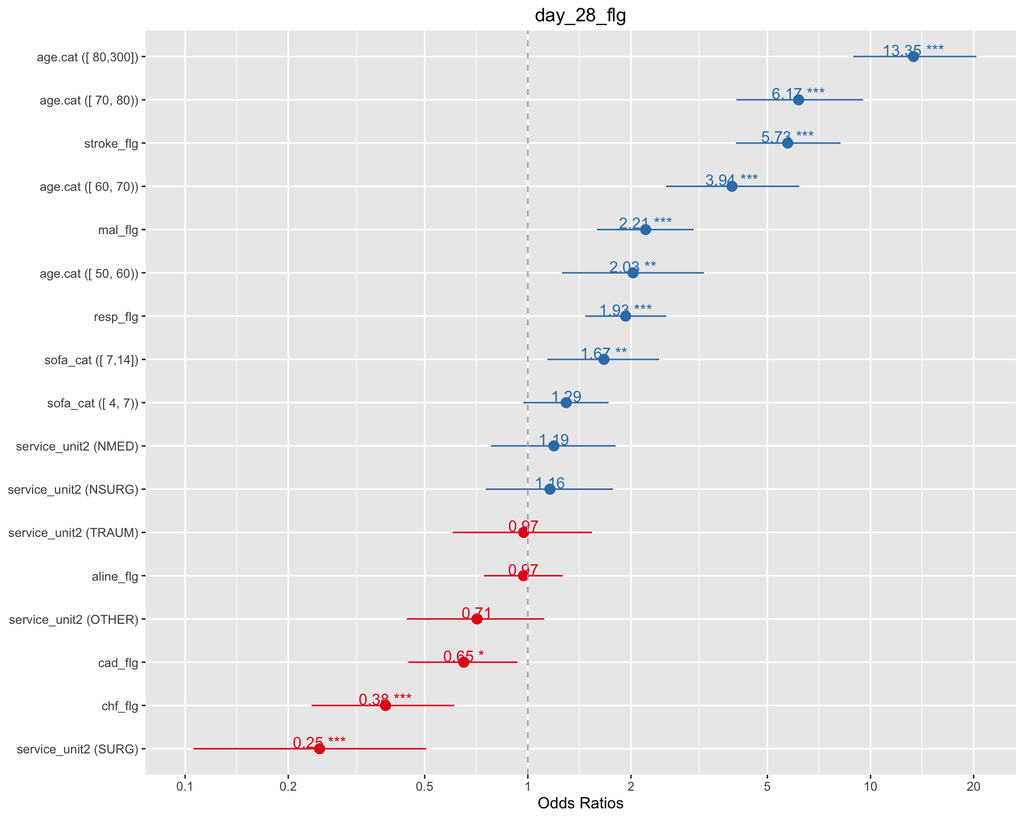

```r
# b
sjp.glm(fit9.glm)
```

```r
# c
library(MASS)
full.model <- glm(day_28_flg ~ aline_flg + age.cat + sofa_cat + service_unit2 + renal_flg + chf_flg + cad_flg + stroke_flg + mal_flg + resp_flg, data=dat, family="binomial")
stepAIC(full.model, scope=list(lower=~aline_flg)) # AIC
```

```
## Start:  AIC=1775.17
## day_28_flg ~ aline_flg + age.cat + sofa_cat + service_unit2 +
##     renal_flg + chf_flg + cad_flg + stroke_flg + mal_flg + resp_flg
##
##                 Df Deviance    AIC
## - renal_flg      1   1737.2 1773.2
## <none>               1737.2 1775.2
## - cad_flg        1   1742.7 1778.7
## - sofa_cat       2   1745.5 1779.5
## - service_unit2  5   1759.0 1787.0
## - chf_flg        1   1754.5 1790.5
## - mal_flg        1   1759.1 1795.1
## - resp_flg       1   1759.7 1795.7
## - stroke_flg     1   1837.9 1873.9
## - age.cat        4   1941.6 1971.6
##
## Step:  AIC=1773.19
## day_28_flg ~ aline_flg + age.cat + sofa_cat + service_unit2 +
##     chf_flg + cad_flg + stroke_flg + mal_flg + resp_flg
##
##                 Df Deviance    AIC
## <none>               1737.2 1773.2
## - cad_flg        1   1742.7 1776.7
## - sofa_cat       2   1745.5 1777.5
## - service_unit2  5   1759.0 1785.0
## - chf_flg        1   1754.8 1788.8
## - mal_flg        1   1759.1 1793.1
## - resp_flg       1   1759.8 1793.8
## - stroke_flg     1   1838.0 1872.0
## - age.cat        4   1942.8 1970.8
```

```
##
## Call:  glm(formula = day_28_flg ~ aline_flg + age.cat + sofa_cat + service_unit2 +
##     chf_flg + cad_flg + stroke_flg + mal_flg + resp_flg, family = "binomial",
##     data = dat)
##
## Coefficients:
##        (Intercept)           aline_flg    age.cat[ 50, 60)
##           -3.79877            -0.02914             0.70676
##   age.cat[ 60, 70)    age.cat[ 70, 80)    age.cat[ 80,300]
##            1.37180             1.81940             2.59117
##    sofa_cat[ 4, 7)     sofa_cat[ 7,14]   service_unit2NMED
##            0.25822             0.51130             0.17545
## service_unit2NSURG  service_unit2OTHER   service_unit2SURG
##            0.14880            -0.34097            -1.39935
## service_unit2TRAUM             chf_flg             cad_flg
##           -0.02786            -0.95620            -0.43043
##         stroke_flg             mal_flg            resp_flg
##            1.74619             0.79157             0.65748
##
## Degrees of Freedom: 2750 Total (i.e. Null);  2733 Residual
## Null Deviance:       2341
## Residual Deviance: 1737  AIC: 1773
```

```r
# d
stepAIC(full.model, scope=list(lower=~aline_flg), k=log(nrow(dat))) # BIC
```

```
## Start:  AIC=1887.65
## day_28_flg ~ aline_flg + age.cat + sofa_cat + service_unit2 +
##     renal_flg + chf_flg + cad_flg + stroke_flg + mal_flg + resp_flg
##
##                 Df Deviance    AIC
## - service_unit2  5   1759.0 1869.9
## - renal_flg      1   1737.2 1879.8
## - sofa_cat       2   1745.5 1880.1
## - cad_flg        1   1742.7 1885.2
## <none>               1737.2 1887.7
## - chf_flg        1   1754.5 1897.0
## - mal_flg        1   1759.1 1901.7
## - resp_flg       1   1759.7 1902.3
## - stroke_flg     1   1837.9 1980.5
## - age.cat        4   1941.6 2060.4
##
## Step:  AIC=1869.9
## day_28_flg ~ aline_flg + age.cat + sofa_cat + renal_flg + chf_flg +
##     cad_flg + stroke_flg + mal_flg + resp_flg
##
##              Df Deviance    AIC
## - sofa_cat    2   1766.4 1861.5
## - renal_flg   1   1759.0 1862.0
## - cad_flg     1   1766.4 1869.4
## <none>            1759.0 1869.9
## - mal_flg     1   1775.8 1878.8
## - chf_flg     1   1776.4 1879.3
## - resp_flg    1   1787.1 1890.0
## - age.cat     4   1970.7 2049.9
## - stroke_flg  1   1959.5 2062.5
##
## Step:  AIC=1861.46
## day_28_flg ~ aline_flg + age.cat + renal_flg + chf_flg + cad_flg +
##     stroke_flg + mal_flg + resp_flg
##
##              Df Deviance    AIC
## - renal_flg   1   1766.5 1853.6
## - cad_flg     1   1774.2 1861.3
## <none>            1766.4 1861.5
## - mal_flg     1   1785.0 1872.1
```

[output cut: 14 more lines]

```
## - resp_flg    1   1797.0 1876.2
## - age.cat     4   1983.8 2039.2
## - stroke_flg  1   1964.8 2044.0
##
## Step:  AIC=1853.42
## day_28_flg ~ aline_flg + age.cat + chf_flg + stroke_flg + mal_flg +
##     resp_flg
##
##              Df Deviance    AIC
## <none>            1774.2 1853.4
## - mal_flg     1   1794.4 1865.7
## - chf_flg     1   1798.5 1869.8
## - resp_flg    1   1806.6 1877.9
## - age.cat     4   1983.8 2031.3
## - stroke_flg  1   1974.6 2045.9
```

```
##
## Call:  glm(formula = day_28_flg ~ aline_flg + age.cat + chf_flg + stroke_flg +
##     mal_flg + resp_flg, family = "binomial", data = dat)
##
## Coefficients:
##      (Intercept)         aline_flg  age.cat[ 50, 60)  age.cat[ 60, 70)
##          -3.7383           -0.1257            0.6355            1.2938
## age.cat[ 70, 80)  age.cat[ 80,300]           chf_flg        stroke_flg
##           1.6986            2.5066           -1.0843            1.9869
##          mal_flg          resp_flg
##           0.7289            0.7331
##
## Degrees of Freedom: 2750 Total (i.e. Null);  2741 Residual
## Null Deviance:       2341
## Residual Deviance: 1774  AIC: 1794
```